# Counter projection on downstream outcomes

### Willingness with binding data

```r
discuss_coeff_bind <- lm(WilltoDiscuss ~ MFQSelf_c*`MFQSelf_c:inoutgroup_effects`*`MFQSelf_c:ident_c`*`MFQSelf_c:inoutgroup_effects:ident_c`, data = downstream_coeffs_bind)
summary(discuss_coeff_bind)
```

```
##
## Call:
## lm(formula = WilltoDiscuss ~ MFQSelf_c * `MFQSelf_c:inoutgroup_effects` *
##     `MFQSelf_c:ident_c` * `MFQSelf_c:inoutgroup_effects:ident_c`,
##     data = downstream_coeffs_bind)
##
## Residuals:
##     Min      1Q  Median      3Q     Max
## -4.3181 -1.0979  0.2413  1.7868  2.5792
##
## Coefficients: (14 not defined because of singularities)
##                                                                                                     Estimate
## (Intercept)                                                                                          4.75351
## MFQSelf_c                                                                                            1.04463
## `MFQSelf_c:inoutgroup_effects`                                                                            NA
## `MFQSelf_c:ident_c`                                                                                       NA
## `MFQSelf_c:inoutgroup_effects:ident_c`                                                                    NA
## MFQSelf_c:`MFQSelf_c:inoutgroup_effects`                                                                  NA
## MFQSelf_c:`MFQSelf_c:ident_c`                                                                             NA
## `MFQSelf_c:inoutgroup_effects`:`MFQSelf_c:ident_c`                                                        NA
## MFQSelf_c:`MFQSelf_c:inoutgroup_effects:ident_c`                                                          NA
## `MFQSelf_c:inoutgroup_effects`:`MFQSelf_c:inoutgroup_effects:ident_c`                                     NA
## `MFQSelf_c:ident_c`:`MFQSelf_c:inoutgroup_effects:ident_c`                                                NA
## MFQSelf_c:`MFQSelf_c:inoutgroup_effects`:`MFQSelf_c:ident_c`                                              NA
## MFQSelf_c:`MFQSelf_c:inoutgroup_effects`:`MFQSelf_c:inoutgroup_effects:ident_c`                           NA
## MFQSelf_c:`MFQSelf_c:ident_c`:`MFQSelf_c:inoutgroup_effects:ident_c`                                      NA
## `MFQSelf_c:inoutgroup_effects`:`MFQSelf_c:ident_c`:`MFQSelf_c:inoutgroup_effects:ident_c`                 NA
## MFQSelf_c:`MFQSelf_c:inoutgroup_effects`:`MFQSelf_c:ident_c`:`MFQSelf_c:inoutgroup_effects:ident_c`       NA
##                                                                                                     Std. Error
## (Intercept)                                                                                            0.09575
## MFQSelf_c                                                                                              0.48233
## `MFQSelf_c:inoutgroup_effects`                                                                              NA
## `MFQSelf_c:ident_c`                                                                                         NA
## `MFQSelf_c:inoutgroup_effects:ident_c`                                                                      NA
## MFQSelf_c:`MFQSelf_c:inoutgroup_effects`                                                                    NA
## MFQSelf_c:`MFQSelf_c:ident_c`                                                                               NA
## `MFQSelf_c:inoutgroup_effects`:`MFQSelf_c:ident_c`                                                          NA
## MFQSelf_c:`MFQSelf_c:inoutgroup_effects:ident_c`                                                            NA
## `MFQSelf_c:inoutgroup_effects`:`MFQSelf_c:inoutgroup_effects:ident_c`                                       NA
## `MFQSelf_c:ident_c`:`MFQSelf_c:inoutgroup_effects:ident_c`                                                  NA
```

[output cut: 47 more lines]

```
## `MFQSelf_c:inoutgroup_effects`:`MFQSelf_c:ident_c`
## MFQSelf_c:`MFQSelf_c:inoutgroup_effects:ident_c`
## `MFQSelf_c:inoutgroup_effects`:`MFQSelf_c:inoutgroup_effects:ident_c`
## `MFQSelf_c:ident_c`:`MFQSelf_c:inoutgroup_effects:ident_c`
## MFQSelf_c:`MFQSelf_c:inoutgroup_effects`:`MFQSelf_c:ident_c`
## MFQSelf_c:`MFQSelf_c:inoutgroup_effects`:`MFQSelf_c:inoutgroup_effects:ident_c`
## MFQSelf_c:`MFQSelf_c:ident_c`:`MFQSelf_c:inoutgroup_effects:ident_c`
## `MFQSelf_c:inoutgroup_effects`:`MFQSelf_c:ident_c`:`MFQSelf_c:inoutgroup_effects:ident_c`
## MFQSelf_c:`MFQSelf_c:inoutgroup_effects`:`MFQSelf_c:ident_c`:`MFQSelf_c:inoutgroup_effects:ident_c`
## ---
## Signif. codes:  0 '***' 0.001 '**' 0.01 '*' 0.05 '.' 0.1 ' ' 1
##
## Residual standard error: 1.916 on 667 degrees of freedom
## Multiple R-squared:  0.006984,   Adjusted R-squared:  0.005495
## F-statistic: 4.691 on 1 and 667 DF,  p-value: 0.03068
```

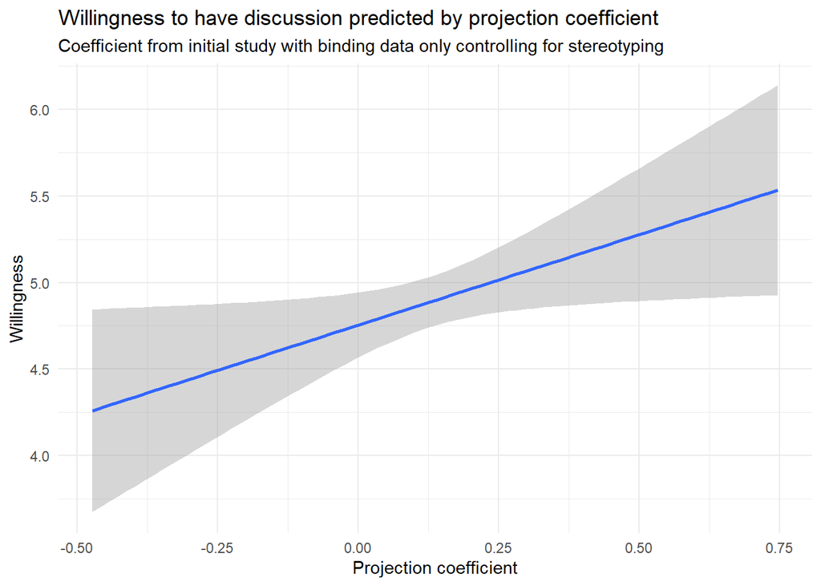

```r
ggplot(downstream_coeffs_bind,aes(MFQSelf_c, WilltoDiscuss)) +
  geom_smooth(method = "lm") +
  labs(title = "Willingness to have discussion predicted by projection coefficient",
       subtitle = "Coefficient from initial study with binding data only controlling for stereotyping",
       x = "Projection coefficient",
       y = "Willingness") +
  theme_minimal()
```

### Willingness with individuating data

```r
discuss_coeff_indiv <- lm(WilltoDiscuss ~ MFQSelf_c*`MFQSelf_c:inoutgroup_effects`*`MFQSelf_c:ident_c`*`MFQSelf_c:inoutgroup_effects:ident_c`, data = downstream_coeffs_indiv)
summary(discuss_coeff_indiv)
```

```
##
## Call:
## lm(formula = WilltoDiscuss ~ MFQSelf_c * `MFQSelf_c:inoutgroup_effects` *
##     `MFQSelf_c:ident_c` * `MFQSelf_c:inoutgroup_effects:ident_c`,
##     data = downstream_coeffs_indiv)
##
## Residuals:
##     Min      1Q  Median      3Q     Max
## -4.3569 -1.0171  0.1831  1.8784  2.5008
##
## Coefficients: (14 not defined because of singularities)
##                                                                                                     Estimate
## (Intercept)                                                                                           4.7324
## MFQSelf_c                                                                                             0.7222
## `MFQSelf_c:inoutgroup_effects`                                                                            NA
## `MFQSelf_c:ident_c`                                                                                       NA
## `MFQSelf_c:inoutgroup_effects:ident_c`                                                                    NA
## MFQSelf_c:`MFQSelf_c:inoutgroup_effects`                                                                  NA
## MFQSelf_c:`MFQSelf_c:ident_c`                                                                             NA
## `MFQSelf_c:inoutgroup_effects`:`MFQSelf_c:ident_c`                                                        NA
## MFQSelf_c:`MFQSelf_c:inoutgroup_effects:ident_c`                                                          NA
## `MFQSelf_c:inoutgroup_effects`:`MFQSelf_c:inoutgroup_effects:ident_c`                                     NA
## `MFQSelf_c:ident_c`:`MFQSelf_c:inoutgroup_effects:ident_c`                                                NA
## MFQSelf_c:`MFQSelf_c:inoutgroup_effects`:`MFQSelf_c:ident_c`                                              NA
## MFQSelf_c:`MFQSelf_c:inoutgroup_effects`:`MFQSelf_c:inoutgroup_effects:ident_c`                           NA
## MFQSelf_c:`MFQSelf_c:ident_c`:`MFQSelf_c:inoutgroup_effects:ident_c`                                      NA
## `MFQSelf_c:inoutgroup_effects`:`MFQSelf_c:ident_c`:`MFQSelf_c:inoutgroup_effects:ident_c`                 NA
## MFQSelf_c:`MFQSelf_c:inoutgroup_effects`:`MFQSelf_c:ident_c`:`MFQSelf_c:inoutgroup_effects:ident_c`       NA
##                                                                                                     Std. Error
## (Intercept)                                                                                             0.1163
## MFQSelf_c                                                                                               0.4239
## `MFQSelf_c:inoutgroup_effects`                                                                              NA
## `MFQSelf_c:ident_c`                                                                                         NA
## `MFQSelf_c:inoutgroup_effects:ident_c`                                                                      NA
## MFQSelf_c:`MFQSelf_c:inoutgroup_effects`                                                                    NA
## MFQSelf_c:`MFQSelf_c:ident_c`                                                                               NA
## `MFQSelf_c:inoutgroup_effects`:`MFQSelf_c:ident_c`                                                          NA
## MFQSelf_c:`MFQSelf_c:inoutgroup_effects:ident_c`                                                            NA
## `MFQSelf_c:inoutgroup_effects`:`MFQSelf_c:inoutgroup_effects:ident_c`                                       NA
## `MFQSelf_c:ident_c`:`MFQSelf_c:inoutgroup_effects:ident_c`                                                  NA
```

[output cut: 47 more lines]

```
## `MFQSelf_c:inoutgroup_effects`:`MFQSelf_c:ident_c`
## MFQSelf_c:`MFQSelf_c:inoutgroup_effects:ident_c`
## `MFQSelf_c:inoutgroup_effects`:`MFQSelf_c:inoutgroup_effects:ident_c`
## `MFQSelf_c:ident_c`:`MFQSelf_c:inoutgroup_effects:ident_c`
## MFQSelf_c:`MFQSelf_c:inoutgroup_effects`:`MFQSelf_c:ident_c`
## MFQSelf_c:`MFQSelf_c:inoutgroup_effects`:`MFQSelf_c:inoutgroup_effects:ident_c`
## MFQSelf_c:`MFQSelf_c:ident_c`:`MFQSelf_c:inoutgroup_effects:ident_c`
## `MFQSelf_c:inoutgroup_effects`:`MFQSelf_c:ident_c`:`MFQSelf_c:inoutgroup_effects:ident_c`
## MFQSelf_c:`MFQSelf_c:inoutgroup_effects`:`MFQSelf_c:ident_c`:`MFQSelf_c:inoutgroup_effects:ident_c`
## ---
## Signif. codes:  0 '***' 0.001 '**' 0.01 '*' 0.05 '.' 0.1 ' ' 1
##
## Residual standard error: 1.919 on 667 degrees of freedom
## Multiple R-squared:  0.004332,   Adjusted R-squared:  0.002839
## F-statistic: 2.902 on 1 and 667 DF,  p-value: 0.08895
```

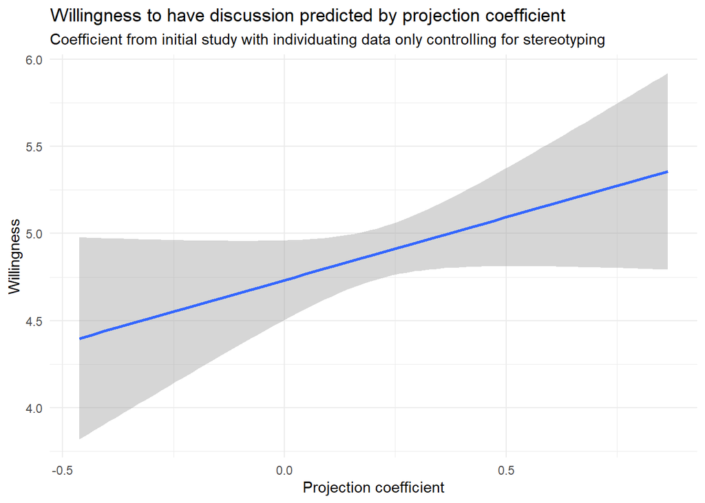

```r
ggplot(downstream_coeffs_indiv,aes(MFQSelf_c, WilltoDiscuss)) +
  geom_smooth(method = "lm") +
  labs(title = "Willingness to have discussion predicted by projection coefficient",
       subtitle = "Coefficient from initial study with individuating data only controlling for stereotyping",
       x = "Projection coefficient",
       y = "Willingness") +
  theme_minimal()
```

The effect was there with the binding data, but is only marginal with the individuating data.

## Contentiousness predicted by coefficients

```r
content_coeffs <- lm(Contentious ~ MFQSelf_c*`MFQSelf_c:inoutgroup_effects`*`MFQSelf_c:ident_c`*`MFQSelf_c:inoutgroup_effects:ident_c`, data = downstream_coeffs)
summary(content_coeffs)
```

```
##
## Call:
## lm(formula = Contentious ~ MFQSelf_c * `MFQSelf_c:inoutgroup_effects` *
##     `MFQSelf_c:ident_c` * `MFQSelf_c:inoutgroup_effects:ident_c`,
##     data = downstream_coeffs)
##
## Residuals:
##     Min      1Q  Median      3Q     Max
## -4.3225 -1.6000  0.0448  1.6434  4.1309
##
## Coefficients: (14 not defined because of singularities)
##                                                                                                     Estimate
## (Intercept)                                                                                          4.30714
## MFQSelf_c                                                                                           -1.95072
## `MFQSelf_c:inoutgroup_effects`                                                                            NA
## `MFQSelf_c:ident_c`                                                                                       NA
## `MFQSelf_c:inoutgroup_effects:ident_c`                                                                    NA
## MFQSelf_c:`MFQSelf_c:inoutgroup_effects`                                                                  NA
## MFQSelf_c:`MFQSelf_c:ident_c`                                                                             NA
## `MFQSelf_c:inoutgroup_effects`:`MFQSelf_c:ident_c`                                                        NA
## MFQSelf_c:`MFQSelf_c:inoutgroup_effects:ident_c`                                                          NA
## `MFQSelf_c:inoutgroup_effects`:`MFQSelf_c:inoutgroup_effects:ident_c`                                     NA
## `MFQSelf_c:ident_c`:`MFQSelf_c:inoutgroup_effects:ident_c`                                                NA
## MFQSelf_c:`MFQSelf_c:inoutgroup_effects`:`MFQSelf_c:ident_c`                                              NA
## MFQSelf_c:`MFQSelf_c:inoutgroup_effects`:`MFQSelf_c:inoutgroup_effects:ident_c`                           NA
## MFQSelf_c:`MFQSelf_c:ident_c`:`MFQSelf_c:inoutgroup_effects:ident_c`                                      NA
## `MFQSelf_c:inoutgroup_effects`:`MFQSelf_c:ident_c`:`MFQSelf_c:inoutgroup_effects:ident_c`                 NA
## MFQSelf_c:`MFQSelf_c:inoutgroup_effects`:`MFQSelf_c:ident_c`:`MFQSelf_c:inoutgroup_effects:ident_c`       NA
##                                                                                                     Std. Error
## (Intercept)                                                                                            0.08439
## MFQSelf_c                                                                                              0.29096
## `MFQSelf_c:inoutgroup_effects`                                                                              NA
## `MFQSelf_c:ident_c`                                                                                         NA
## `MFQSelf_c:inoutgroup_effects:ident_c`                                                                      NA
## MFQSelf_c:`MFQSelf_c:inoutgroup_effects`                                                                    NA
## MFQSelf_c:`MFQSelf_c:ident_c`                                                                               NA
## `MFQSelf_c:inoutgroup_effects`:`MFQSelf_c:ident_c`                                                          NA
## MFQSelf_c:`MFQSelf_c:inoutgroup_effects:ident_c`                                                            NA
## `MFQSelf_c:inoutgroup_effects`:`MFQSelf_c:inoutgroup_effects:ident_c`                                       NA
## `MFQSelf_c:ident_c`:`MFQSelf_c:inoutgroup_effects:ident_c`                                                  NA
```

[output cut: 48 more lines]

```
## MFQSelf_c:`MFQSelf_c:inoutgroup_effects:ident_c`
## `MFQSelf_c:inoutgroup_effects`:`MFQSelf_c:inoutgroup_effects:ident_c`
## `MFQSelf_c:ident_c`:`MFQSelf_c:inoutgroup_effects:ident_c`
## MFQSelf_c:`MFQSelf_c:inoutgroup_effects`:`MFQSelf_c:ident_c`
## MFQSelf_c:`MFQSelf_c:inoutgroup_effects`:`MFQSelf_c:inoutgroup_effects:ident_c`
## MFQSelf_c:`MFQSelf_c:ident_c`:`MFQSelf_c:inoutgroup_effects:ident_c`
## `MFQSelf_c:inoutgroup_effects`:`MFQSelf_c:ident_c`:`MFQSelf_c:inoutgroup_effects:ident_c`
## MFQSelf_c:`MFQSelf_c:inoutgroup_effects`:`MFQSelf_c:ident_c`:`MFQSelf_c:inoutgroup_effects:ident_c`
## ---
## Signif. codes:  0 '***' 0.001 '**' 0.01 '*' 0.05 '.' 0.1 ' ' 1
##
## Residual standard error: 1.899 on 667 degrees of freedom
##   (5 observations deleted due to missingness)
## Multiple R-squared:  0.06313,    Adjusted R-squared:  0.06173
## F-statistic: 44.95 on 1 and 667 DF,  p-value: 0.00000000004313
```

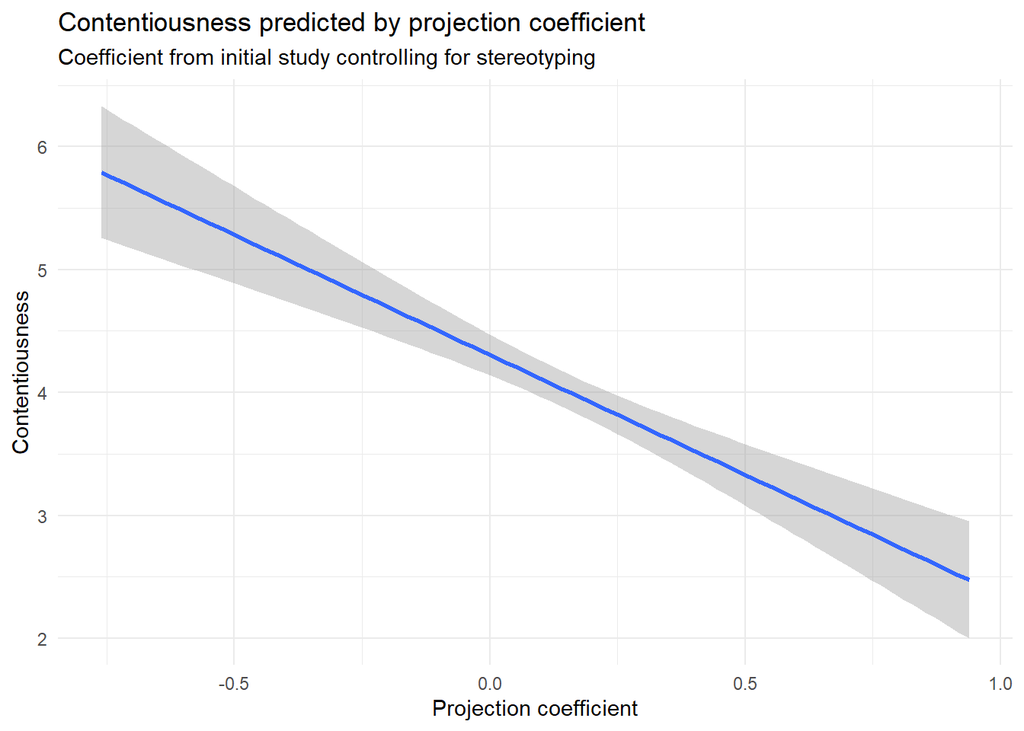

```r
ggplot(downstream_coeffs,aes(MFQSelf_c, Contentious)) +
  geom_smooth(method = "lm") +
  labs(title = "Contentiousness predicted by projection coefficient",
       subtitle = "Coefficient from initial study controlling for stereotyping",
       x = "Projection coefficient",
       y = "Contentiousness") +
  theme_minimal()
```

### Contentiousness with difference scores too

```r
content_codiff <- lm(Contentious ~ MFQSelf_c*proj_diff, coeffs_and_diffs)
summary(content_codiff)
```

```
##
## Call:
## lm(formula = Contentious ~ MFQSelf_c * proj_diff, data = coeffs_and_diffs)
##
## Residuals:
##     Min      1Q  Median      3Q     Max
## -4.4950 -1.6050  0.1114  1.5978  3.8107
##
## Coefficients:
##                     Estimate Std. Error t value             Pr(>|t|)
## (Intercept)          4.10228    0.14030  29.240 < 0.0000000000000002 ***
## MFQSelf_c           -1.75318    0.48427  -3.620             0.000317 ***
## proj_diff            0.30945    0.15850   1.952             0.051307 .
## MFQSelf_c:proj_diff -0.08051    0.61784  -0.130             0.896364
## ---
## Signif. codes:  0 '***' 0.001 '**' 0.01 '*' 0.05 '.' 0.1 ' ' 1
##
## Residual standard error: 1.896 on 665 degrees of freedom
##   (5 observations deleted due to missingness)
## Multiple R-squared:  0.06925,    Adjusted R-squared:  0.06506
## F-statistic: 16.49 on 3 and 665 DF,  p-value: 0.0000000002392
```

Projection is significant, but the difference score is only marginal.

### Contentiousness with binding data

```r
content_coeff_bind <- lm(Contentious ~ MFQSelf_c*`MFQSelf_c:inoutgroup_effects`*`MFQSelf_c:ident_c`*`MFQSelf_c:inoutgroup_effects:ident_c`, data = downstream_coeffs_bind)
summary(content_coeff_bind)
```

```
##
## Call:
## lm(formula = Contentious ~ MFQSelf_c * `MFQSelf_c:inoutgroup_effects` *
##     `MFQSelf_c:ident_c` * `MFQSelf_c:inoutgroup_effects:ident_c`,
##     data = downstream_coeffs_bind)
##
## Residuals:
##     Min      1Q  Median      3Q     Max
## -3.8278 -1.6903  0.0235  1.7339  3.5124
##
## Coefficients: (14 not defined because of singularities)
##                                                                                                     Estimate
## (Intercept)                                                                                          4.30173
## MFQSelf_c                                                                                           -2.17300
## `MFQSelf_c:inoutgroup_effects`                                                                            NA
## `MFQSelf_c:ident_c`                                                                                       NA
## `MFQSelf_c:inoutgroup_effects:ident_c`                                                                    NA
## MFQSelf_c:`MFQSelf_c:inoutgroup_effects`                                                                  NA
## MFQSelf_c:`MFQSelf_c:ident_c`                                                                             NA
## `MFQSelf_c:inoutgroup_effects`:`MFQSelf_c:ident_c`                                                        NA
## MFQSelf_c:`MFQSelf_c:inoutgroup_effects:ident_c`                                                          NA
## `MFQSelf_c:inoutgroup_effects`:`MFQSelf_c:inoutgroup_effects:ident_c`                                     NA
## `MFQSelf_c:ident_c`:`MFQSelf_c:inoutgroup_effects:ident_c`                                                NA
## MFQSelf_c:`MFQSelf_c:inoutgroup_effects`:`MFQSelf_c:ident_c`                                              NA
## MFQSelf_c:`MFQSelf_c:inoutgroup_effects`:`MFQSelf_c:inoutgroup_effects:ident_c`                           NA
## MFQSelf_c:`MFQSelf_c:ident_c`:`MFQSelf_c:inoutgroup_effects:ident_c`                                      NA
## `MFQSelf_c:inoutgroup_effects`:`MFQSelf_c:ident_c`:`MFQSelf_c:inoutgroup_effects:ident_c`                 NA
## MFQSelf_c:`MFQSelf_c:inoutgroup_effects`:`MFQSelf_c:ident_c`:`MFQSelf_c:inoutgroup_effects:ident_c`       NA
##                                                                                                     Std. Error
## (Intercept)                                                                                            0.09663
## MFQSelf_c                                                                                              0.48674
## `MFQSelf_c:inoutgroup_effects`                                                                              NA
## `MFQSelf_c:ident_c`                                                                                         NA
## `MFQSelf_c:inoutgroup_effects:ident_c`                                                                      NA
## MFQSelf_c:`MFQSelf_c:inoutgroup_effects`                                                                    NA
## MFQSelf_c:`MFQSelf_c:ident_c`                                                                               NA
## `MFQSelf_c:inoutgroup_effects`:`MFQSelf_c:ident_c`                                                          NA
## MFQSelf_c:`MFQSelf_c:inoutgroup_effects:ident_c`                                                            NA
## `MFQSelf_c:inoutgroup_effects`:`MFQSelf_c:inoutgroup_effects:ident_c`                                       NA
## `MFQSelf_c:ident_c`:`MFQSelf_c:inoutgroup_effects:ident_c`                                                  NA
```

[output cut: 47 more lines]

```
## `MFQSelf_c:inoutgroup_effects`:`MFQSelf_c:ident_c`
## MFQSelf_c:`MFQSelf_c:inoutgroup_effects:ident_c`
## `MFQSelf_c:inoutgroup_effects`:`MFQSelf_c:inoutgroup_effects:ident_c`
## `MFQSelf_c:ident_c`:`MFQSelf_c:inoutgroup_effects:ident_c`
## MFQSelf_c:`MFQSelf_c:inoutgroup_effects`:`MFQSelf_c:ident_c`
## MFQSelf_c:`MFQSelf_c:inoutgroup_effects`:`MFQSelf_c:inoutgroup_effects:ident_c`
## MFQSelf_c:`MFQSelf_c:ident_c`:`MFQSelf_c:inoutgroup_effects:ident_c`
## `MFQSelf_c:inoutgroup_effects`:`MFQSelf_c:ident_c`:`MFQSelf_c:inoutgroup_effects:ident_c`
## MFQSelf_c:`MFQSelf_c:inoutgroup_effects`:`MFQSelf_c:ident_c`:`MFQSelf_c:inoutgroup_effects:ident_c`
## ---
## Signif. codes:  0 '***' 0.001 '**' 0.01 '*' 0.05 '.' 0.1 ' ' 1
##
## Residual standard error: 1.934 on 667 degrees of freedom
## Multiple R-squared:  0.02901,    Adjusted R-squared:  0.02756
## F-statistic: 19.93 on 1 and 667 DF,  p-value: 0.000009426
```

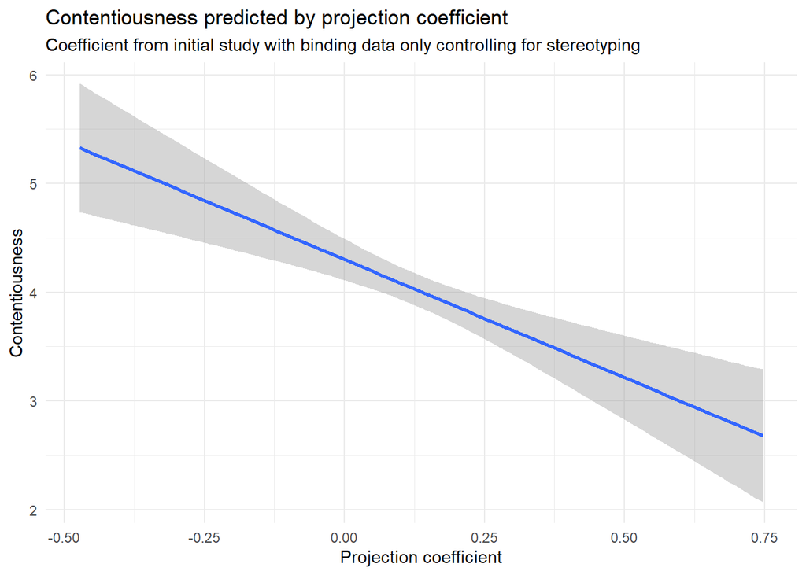

```r
ggplot(downstream_coeffs_bind,aes(MFQSelf_c, Contentious)) +
  geom_smooth(method = "lm") +
  labs(title = "Contentiousness predicted by projection coefficient",
       subtitle = "Coefficient from initial study with binding data only controlling for stereotyping",
       x = "Projection coefficient",
       y = "Contentiousness") +
  theme_minimal()
```

### Contentiousness with individuating data

```r
content_coeff_indiv <- lm(Contentious ~ MFQSelf_c*`MFQSelf_c:inoutgroup_effects`*`MFQSelf_c:ident_c`*`MFQSelf_c:inoutgroup_effects:ident_c`, data = downstream_coeffs_indiv)
summary(content_coeff_indiv)
```

```
##
## Call:
## lm(formula = Contentious ~ MFQSelf_c * `MFQSelf_c:inoutgroup_effects` *
##     `MFQSelf_c:ident_c` * `MFQSelf_c:inoutgroup_effects:ident_c`,
##     data = downstream_coeffs_indiv)
##
## Residuals:
##     Min      1Q  Median      3Q     Max
## -3.8421 -1.7297  0.0059  1.7249  4.0858
##
## Coefficients: (14 not defined because of singularities)
##                                                                                                     Estimate
## (Intercept)                                                                                           4.3884
## MFQSelf_c                                                                                            -1.7047
## `MFQSelf_c:inoutgroup_effects`                                                                            NA
## `MFQSelf_c:ident_c`                                                                                       NA
## `MFQSelf_c:inoutgroup_effects:ident_c`                                                                    NA
## MFQSelf_c:`MFQSelf_c:inoutgroup_effects`                                                                  NA
## MFQSelf_c:`MFQSelf_c:ident_c`                                                                             NA
## `MFQSelf_c:inoutgroup_effects`:`MFQSelf_c:ident_c`                                                        NA
## MFQSelf_c:`MFQSelf_c:inoutgroup_effects:ident_c`                                                          NA
## `MFQSelf_c:inoutgroup_effects`:`MFQSelf_c:inoutgroup_effects:ident_c`                                     NA
## `MFQSelf_c:ident_c`:`MFQSelf_c:inoutgroup_effects:ident_c`                                                NA
## MFQSelf_c:`MFQSelf_c:inoutgroup_effects`:`MFQSelf_c:ident_c`                                              NA
## MFQSelf_c:`MFQSelf_c:inoutgroup_effects`:`MFQSelf_c:inoutgroup_effects:ident_c`                           NA
## MFQSelf_c:`MFQSelf_c:ident_c`:`MFQSelf_c:inoutgroup_effects:ident_c`                                      NA
## `MFQSelf_c:inoutgroup_effects`:`MFQSelf_c:ident_c`:`MFQSelf_c:inoutgroup_effects:ident_c`                 NA
## MFQSelf_c:`MFQSelf_c:inoutgroup_effects`:`MFQSelf_c:ident_c`:`MFQSelf_c:inoutgroup_effects:ident_c`       NA
##                                                                                                     Std. Error
## (Intercept)                                                                                             0.1175
## MFQSelf_c                                                                                               0.4285
## `MFQSelf_c:inoutgroup_effects`                                                                              NA
## `MFQSelf_c:ident_c`                                                                                         NA
## `MFQSelf_c:inoutgroup_effects:ident_c`                                                                      NA
## MFQSelf_c:`MFQSelf_c:inoutgroup_effects`                                                                    NA
## MFQSelf_c:`MFQSelf_c:ident_c`                                                                               NA
## `MFQSelf_c:inoutgroup_effects`:`MFQSelf_c:ident_c`                                                          NA
## MFQSelf_c:`MFQSelf_c:inoutgroup_effects:ident_c`                                                            NA
## `MFQSelf_c:inoutgroup_effects`:`MFQSelf_c:inoutgroup_effects:ident_c`                                       NA
## `MFQSelf_c:ident_c`:`MFQSelf_c:inoutgroup_effects:ident_c`                                                  NA
```

[output cut: 47 more lines]

```
## `MFQSelf_c:inoutgroup_effects`:`MFQSelf_c:ident_c`
## MFQSelf_c:`MFQSelf_c:inoutgroup_effects:ident_c`
## `MFQSelf_c:inoutgroup_effects`:`MFQSelf_c:inoutgroup_effects:ident_c`
## `MFQSelf_c:ident_c`:`MFQSelf_c:inoutgroup_effects:ident_c`
## MFQSelf_c:`MFQSelf_c:inoutgroup_effects`:`MFQSelf_c:ident_c`
## MFQSelf_c:`MFQSelf_c:inoutgroup_effects`:`MFQSelf_c:inoutgroup_effects:ident_c`
## MFQSelf_c:`MFQSelf_c:ident_c`:`MFQSelf_c:inoutgroup_effects:ident_c`
## `MFQSelf_c:inoutgroup_effects`:`MFQSelf_c:ident_c`:`MFQSelf_c:inoutgroup_effects:ident_c`
## MFQSelf_c:`MFQSelf_c:inoutgroup_effects`:`MFQSelf_c:ident_c`:`MFQSelf_c:inoutgroup_effects:ident_c`
## ---
## Signif. codes:  0 '***' 0.001 '**' 0.01 '*' 0.05 '.' 0.1 ' ' 1
##
## Residual standard error: 1.939 on 667 degrees of freedom
## Multiple R-squared:  0.02317,    Adjusted R-squared:  0.02171
## F-statistic: 15.82 on 1 and 667 DF,  p-value: 0.00007712
```

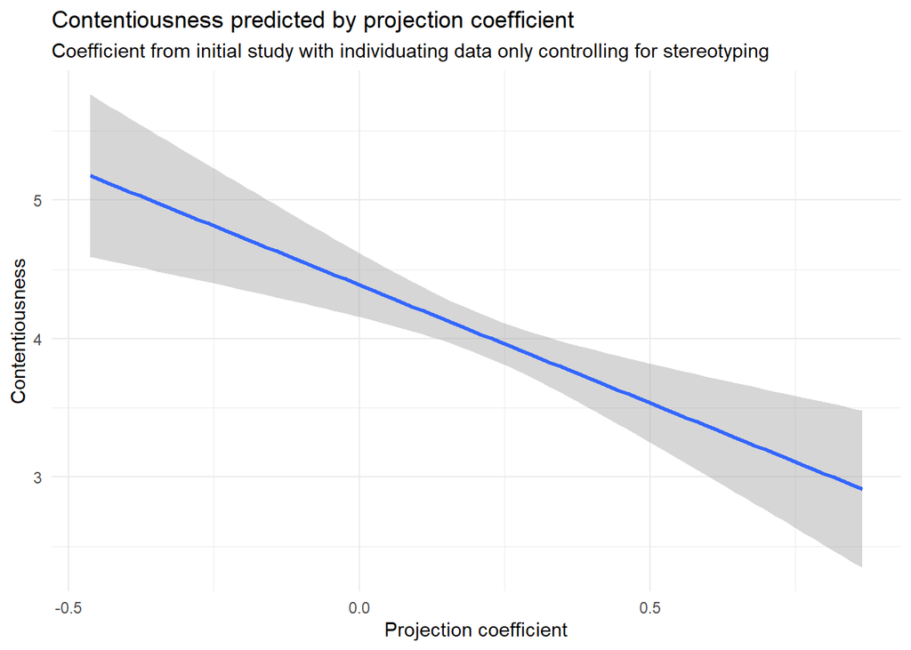

```r
ggplot(downstream_coeffs_indiv,aes(MFQSelf_c, Contentious)) +
  geom_smooth(method = "lm") +
  labs(title = "Contentiousness predicted by projection coefficient",
       subtitle = "Coefficient from initial study with individuating data only controlling for stereotyping",
       x = "Projection coefficient",
       y = "Contentiousness") +
  theme_minimal()
```

The models for individuating and binding data don’t differ much from the overall model.

## Treatment predicted by coefficients

```r
treat_coeffs <- lm(Treatment ~ MFQSelf_c*`MFQSelf_c:inoutgroup_effects`*`MFQSelf_c:ident_c`*`MFQSelf_c:inoutgroup_effects:ident_c`, data = downstream_coeffs)
summary(treat_coeffs)
```

```
##
## Call:
## lm(formula = Treatment ~ MFQSelf_c * `MFQSelf_c:inoutgroup_effects` *
##     `MFQSelf_c:ident_c` * `MFQSelf_c:inoutgroup_effects:ident_c`,
##     data = downstream_coeffs)
##
## Residuals:
##     Min      1Q  Median      3Q     Max
## -5.1786 -1.4518  0.4243  1.5159  3.6319
##
## Coefficients: (14 not defined because of singularities)
##                                                                                                     Estimate
## (Intercept)                                                                                          4.53122
## MFQSelf_c                                                                                            2.23461
## `MFQSelf_c:inoutgroup_effects`                                                                            NA
## `MFQSelf_c:ident_c`                                                                                       NA
## `MFQSelf_c:inoutgroup_effects:ident_c`                                                                    NA
## MFQSelf_c:`MFQSelf_c:inoutgroup_effects`                                                                  NA
## MFQSelf_c:`MFQSelf_c:ident_c`                                                                             NA
## `MFQSelf_c:inoutgroup_effects`:`MFQSelf_c:ident_c`                                                        NA
## MFQSelf_c:`MFQSelf_c:inoutgroup_effects:ident_c`                                                          NA
## `MFQSelf_c:inoutgroup_effects`:`MFQSelf_c:inoutgroup_effects:ident_c`                                     NA
## `MFQSelf_c:ident_c`:`MFQSelf_c:inoutgroup_effects:ident_c`                                                NA
## MFQSelf_c:`MFQSelf_c:inoutgroup_effects`:`MFQSelf_c:ident_c`                                              NA
## MFQSelf_c:`MFQSelf_c:inoutgroup_effects`:`MFQSelf_c:inoutgroup_effects:ident_c`                           NA
## MFQSelf_c:`MFQSelf_c:ident_c`:`MFQSelf_c:inoutgroup_effects:ident_c`                                      NA
## `MFQSelf_c:inoutgroup_effects`:`MFQSelf_c:ident_c`:`MFQSelf_c:inoutgroup_effects:ident_c`                 NA
## MFQSelf_c:`MFQSelf_c:inoutgroup_effects`:`MFQSelf_c:ident_c`:`MFQSelf_c:inoutgroup_effects:ident_c`       NA
##                                                                                                     Std. Error
## (Intercept)                                                                                            0.08175
## MFQSelf_c                                                                                              0.28187
## `MFQSelf_c:inoutgroup_effects`                                                                              NA
## `MFQSelf_c:ident_c`                                                                                         NA
## `MFQSelf_c:inoutgroup_effects:ident_c`                                                                      NA
## MFQSelf_c:`MFQSelf_c:inoutgroup_effects`                                                                    NA
## MFQSelf_c:`MFQSelf_c:ident_c`                                                                               NA
## `MFQSelf_c:inoutgroup_effects`:`MFQSelf_c:ident_c`                                                          NA
## MFQSelf_c:`MFQSelf_c:inoutgroup_effects:ident_c`                                                            NA
## `MFQSelf_c:inoutgroup_effects`:`MFQSelf_c:inoutgroup_effects:ident_c`                                       NA
## `MFQSelf_c:ident_c`:`MFQSelf_c:inoutgroup_effects:ident_c`                                                  NA
```

[output cut: 48 more lines]

```
## MFQSelf_c:`MFQSelf_c:inoutgroup_effects:ident_c`
## `MFQSelf_c:inoutgroup_effects`:`MFQSelf_c:inoutgroup_effects:ident_c`
## `MFQSelf_c:ident_c`:`MFQSelf_c:inoutgroup_effects:ident_c`
## MFQSelf_c:`MFQSelf_c:inoutgroup_effects`:`MFQSelf_c:ident_c`
## MFQSelf_c:`MFQSelf_c:inoutgroup_effects`:`MFQSelf_c:inoutgroup_effects:ident_c`
## MFQSelf_c:`MFQSelf_c:ident_c`:`MFQSelf_c:inoutgroup_effects:ident_c`
## `MFQSelf_c:inoutgroup_effects`:`MFQSelf_c:ident_c`:`MFQSelf_c:inoutgroup_effects:ident_c`
## MFQSelf_c:`MFQSelf_c:inoutgroup_effects`:`MFQSelf_c:ident_c`:`MFQSelf_c:inoutgroup_effects:ident_c`
## ---
## Signif. codes:  0 '***' 0.001 '**' 0.01 '*' 0.05 '.' 0.1 ' ' 1
##
## Residual standard error: 1.84 on 667 degrees of freedom
##   (5 observations deleted due to missingness)
## Multiple R-squared:  0.08611,    Adjusted R-squared:  0.08474
## F-statistic: 62.85 on 1 and 667 DF,  p-value: 0.000000000000009398
```

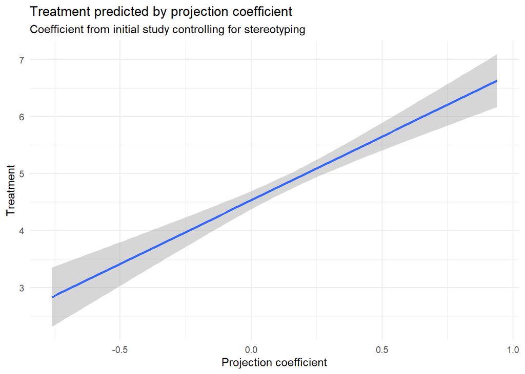

```r
ggplot(downstream_coeffs,aes(MFQSelf_c, Treatment)) +
  geom_smooth(method = "lm") +
  labs(title = "Treatment predicted by projection coefficient",
       subtitle = "Coefficient from initial study controlling for stereotyping",
       x = "Projection coefficient") +
  theme_minimal()
```

### Treatment with difference scores too

```r
treat_codiff <- lm(Treatment ~ MFQSelf_c*proj_diff, coeffs_and_diffs)
summary(treat_codiff)
```

```
##
## Call:
## lm(formula = Treatment ~ MFQSelf_c * proj_diff, data = coeffs_and_diffs)
##
## Residuals:
##     Min      1Q  Median      3Q     Max
## -4.9667 -1.3728  0.4417  1.4476  3.9042
##
## Coefficients:
##                     Estimate Std. Error t value             Pr(>|t|)
## (Intercept)           5.0318     0.1330  37.833 < 0.0000000000000002 ***
## MFQSelf_c             1.9712     0.4591   4.294          0.000020189 ***
## proj_diff            -0.7737     0.1503  -5.149          0.000000345 ***
## MFQSelf_c:proj_diff  -0.2071     0.5857  -0.354                0.724
## ---
## Signif. codes:  0 '***' 0.001 '**' 0.01 '*' 0.05 '.' 0.1 ' ' 1
##
## Residual standard error: 1.797 on 665 degrees of freedom
##   (5 observations deleted due to missingness)
## Multiple R-squared:  0.1306, Adjusted R-squared:  0.1267
## F-statistic:  33.3 on 3 and 665 DF,  p-value: < 0.00000000000000022
```

Both have main effects but the interaction is not significant.

### Treatment with binding data

```r
treat_coeff_bind <- lm(Treatment ~ MFQSelf_c*`MFQSelf_c:inoutgroup_effects`*`MFQSelf_c:ident_c`*`MFQSelf_c:inoutgroup_effects:ident_c`, data = downstream_coeffs_bind)
summary(treat_coeff_bind)
```

```
##
## Call:
## lm(formula = Treatment ~ MFQSelf_c * `MFQSelf_c:inoutgroup_effects` *
##     `MFQSelf_c:ident_c` * `MFQSelf_c:inoutgroup_effects:ident_c`,
##     data = downstream_coeffs_bind)
##
## Residuals:
##     Min      1Q  Median      3Q     Max
## -4.6927 -1.4613  0.4208  1.5608  3.1452
##
## Coefficients: (14 not defined because of singularities)
##                                                                                                     Estimate
## (Intercept)                                                                                          4.51005
## MFQSelf_c                                                                                            2.70685
## `MFQSelf_c:inoutgroup_effects`                                                                            NA
## `MFQSelf_c:ident_c`                                                                                       NA
## `MFQSelf_c:inoutgroup_effects:ident_c`                                                                    NA
## MFQSelf_c:`MFQSelf_c:inoutgroup_effects`                                                                  NA
## MFQSelf_c:`MFQSelf_c:ident_c`                                                                             NA
## `MFQSelf_c:inoutgroup_effects`:`MFQSelf_c:ident_c`                                                        NA
## MFQSelf_c:`MFQSelf_c:inoutgroup_effects:ident_c`                                                          NA
## `MFQSelf_c:inoutgroup_effects`:`MFQSelf_c:inoutgroup_effects:ident_c`                                     NA
## `MFQSelf_c:ident_c`:`MFQSelf_c:inoutgroup_effects:ident_c`                                                NA
## MFQSelf_c:`MFQSelf_c:inoutgroup_effects`:`MFQSelf_c:ident_c`                                              NA
## MFQSelf_c:`MFQSelf_c:inoutgroup_effects`:`MFQSelf_c:inoutgroup_effects:ident_c`                           NA
## MFQSelf_c:`MFQSelf_c:ident_c`:`MFQSelf_c:inoutgroup_effects:ident_c`                                      NA
## `MFQSelf_c:inoutgroup_effects`:`MFQSelf_c:ident_c`:`MFQSelf_c:inoutgroup_effects:ident_c`                 NA
## MFQSelf_c:`MFQSelf_c:inoutgroup_effects`:`MFQSelf_c:ident_c`:`MFQSelf_c:inoutgroup_effects:ident_c`       NA
##                                                                                                     Std. Error
## (Intercept)                                                                                            0.09391
## MFQSelf_c                                                                                              0.47303
## `MFQSelf_c:inoutgroup_effects`                                                                              NA
## `MFQSelf_c:ident_c`                                                                                         NA
## `MFQSelf_c:inoutgroup_effects:ident_c`                                                                      NA
## MFQSelf_c:`MFQSelf_c:inoutgroup_effects`                                                                    NA
## MFQSelf_c:`MFQSelf_c:ident_c`                                                                               NA
## `MFQSelf_c:inoutgroup_effects`:`MFQSelf_c:ident_c`                                                          NA
## MFQSelf_c:`MFQSelf_c:inoutgroup_effects:ident_c`                                                            NA
## `MFQSelf_c:inoutgroup_effects`:`MFQSelf_c:inoutgroup_effects:ident_c`                                       NA
## `MFQSelf_c:ident_c`:`MFQSelf_c:inoutgroup_effects:ident_c`                                                  NA
```

[output cut: 47 more lines]

```
## `MFQSelf_c:inoutgroup_effects`:`MFQSelf_c:ident_c`
## MFQSelf_c:`MFQSelf_c:inoutgroup_effects:ident_c`
## `MFQSelf_c:inoutgroup_effects`:`MFQSelf_c:inoutgroup_effects:ident_c`
## `MFQSelf_c:ident_c`:`MFQSelf_c:inoutgroup_effects:ident_c`
## MFQSelf_c:`MFQSelf_c:inoutgroup_effects`:`MFQSelf_c:ident_c`
## MFQSelf_c:`MFQSelf_c:inoutgroup_effects`:`MFQSelf_c:inoutgroup_effects:ident_c`
## MFQSelf_c:`MFQSelf_c:ident_c`:`MFQSelf_c:inoutgroup_effects:ident_c`
## `MFQSelf_c:inoutgroup_effects`:`MFQSelf_c:ident_c`:`MFQSelf_c:inoutgroup_effects:ident_c`
## MFQSelf_c:`MFQSelf_c:inoutgroup_effects`:`MFQSelf_c:ident_c`:`MFQSelf_c:inoutgroup_effects:ident_c`
## ---
## Signif. codes:  0 '***' 0.001 '**' 0.01 '*' 0.05 '.' 0.1 ' ' 1
##
## Residual standard error: 1.879 on 667 degrees of freedom
## Multiple R-squared:  0.0468, Adjusted R-squared:  0.04537
## F-statistic: 32.75 on 1 and 667 DF,  p-value: 0.00000001587
```

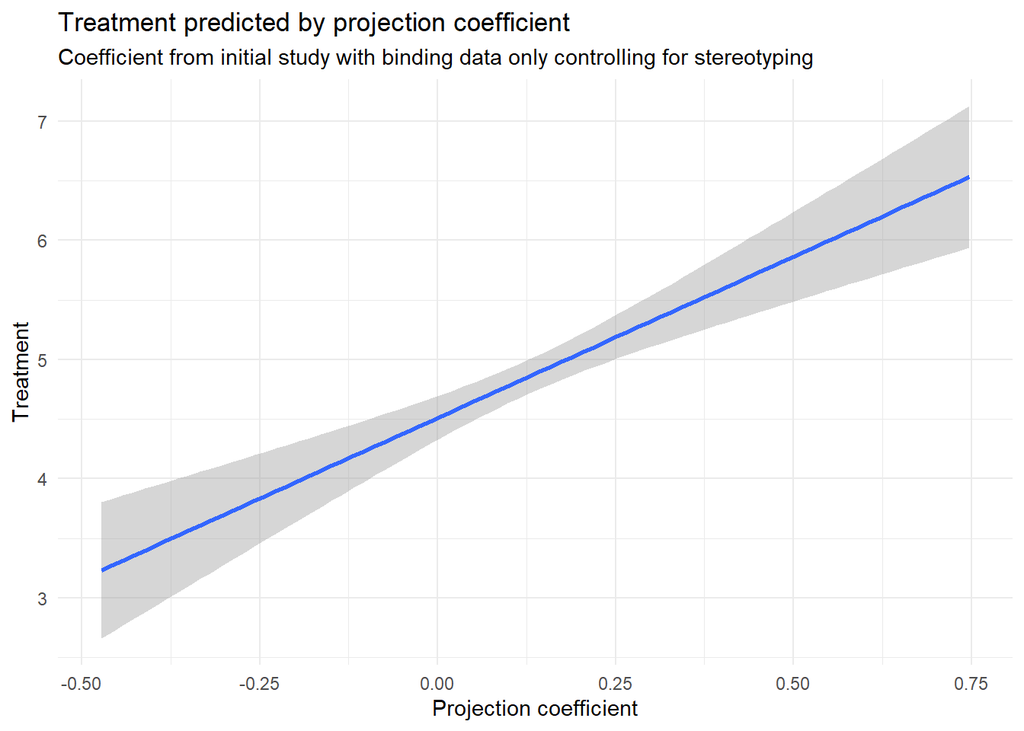

```r
ggplot(downstream_coeffs_bind,aes(MFQSelf_c, Treatment)) +
  geom_smooth(method = "lm") +
  labs(title = "Treatment predicted by projection coefficient",
       subtitle = "Coefficient from initial study with binding data only controlling for stereotyping",
       x = "Projection coefficient") +
  theme_minimal()
```

### Treatment with individuating data

```r
treat_coeff_indiv <- lm(Treatment ~ MFQSelf_c*`MFQSelf_c:inoutgroup_effects`*`MFQSelf_c:ident_c`*`MFQSelf_c:inoutgroup_effects:ident_c`, data = downstream_coeffs_indiv)
summary(treat_coeff_indiv)
```

```
##
## Call:
## lm(formula = Treatment ~ MFQSelf_c * `MFQSelf_c:inoutgroup_effects` *
##     `MFQSelf_c:ident_c` * `MFQSelf_c:inoutgroup_effects:ident_c`,
##     data = downstream_coeffs_indiv)
##
## Residuals:
##     Min      1Q  Median      3Q     Max
## -5.3567 -1.4758  0.4083  1.6451  3.2494
##
## Coefficients: (14 not defined because of singularities)
##                                                                                                     Estimate
## (Intercept)                                                                                           4.3638
## MFQSelf_c                                                                                             2.3044
## `MFQSelf_c:inoutgroup_effects`                                                                            NA
## `MFQSelf_c:ident_c`                                                                                       NA
## `MFQSelf_c:inoutgroup_effects:ident_c`                                                                    NA
## MFQSelf_c:`MFQSelf_c:inoutgroup_effects`                                                                  NA
## MFQSelf_c:`MFQSelf_c:ident_c`                                                                             NA
## `MFQSelf_c:inoutgroup_effects`:`MFQSelf_c:ident_c`                                                        NA
## MFQSelf_c:`MFQSelf_c:inoutgroup_effects:ident_c`                                                          NA
## `MFQSelf_c:inoutgroup_effects`:`MFQSelf_c:inoutgroup_effects:ident_c`                                     NA
## `MFQSelf_c:ident_c`:`MFQSelf_c:inoutgroup_effects:ident_c`                                                NA
## MFQSelf_c:`MFQSelf_c:inoutgroup_effects`:`MFQSelf_c:ident_c`                                              NA
## MFQSelf_c:`MFQSelf_c:inoutgroup_effects`:`MFQSelf_c:inoutgroup_effects:ident_c`                           NA
## MFQSelf_c:`MFQSelf_c:ident_c`:`MFQSelf_c:inoutgroup_effects:ident_c`                                      NA
## `MFQSelf_c:inoutgroup_effects`:`MFQSelf_c:ident_c`:`MFQSelf_c:inoutgroup_effects:ident_c`                 NA
## MFQSelf_c:`MFQSelf_c:inoutgroup_effects`:`MFQSelf_c:ident_c`:`MFQSelf_c:inoutgroup_effects:ident_c`       NA
##                                                                                                     Std. Error
## (Intercept)                                                                                             0.1140
## MFQSelf_c                                                                                               0.4158
## `MFQSelf_c:inoutgroup_effects`                                                                              NA
## `MFQSelf_c:ident_c`                                                                                         NA
## `MFQSelf_c:inoutgroup_effects:ident_c`                                                                      NA
## MFQSelf_c:`MFQSelf_c:inoutgroup_effects`                                                                    NA
## MFQSelf_c:`MFQSelf_c:ident_c`                                                                               NA
## `MFQSelf_c:inoutgroup_effects`:`MFQSelf_c:ident_c`                                                          NA
## MFQSelf_c:`MFQSelf_c:inoutgroup_effects:ident_c`                                                            NA
## `MFQSelf_c:inoutgroup_effects`:`MFQSelf_c:inoutgroup_effects:ident_c`                                       NA
## `MFQSelf_c:ident_c`:`MFQSelf_c:inoutgroup_effects:ident_c`                                                  NA
```

[output cut: 47 more lines]

```
## `MFQSelf_c:inoutgroup_effects`:`MFQSelf_c:ident_c`
## MFQSelf_c:`MFQSelf_c:inoutgroup_effects:ident_c`
## `MFQSelf_c:inoutgroup_effects`:`MFQSelf_c:inoutgroup_effects:ident_c`
## `MFQSelf_c:ident_c`:`MFQSelf_c:inoutgroup_effects:ident_c`
## MFQSelf_c:`MFQSelf_c:inoutgroup_effects`:`MFQSelf_c:ident_c`
## MFQSelf_c:`MFQSelf_c:inoutgroup_effects`:`MFQSelf_c:inoutgroup_effects:ident_c`
## MFQSelf_c:`MFQSelf_c:ident_c`:`MFQSelf_c:inoutgroup_effects:ident_c`
## `MFQSelf_c:inoutgroup_effects`:`MFQSelf_c:ident_c`:`MFQSelf_c:inoutgroup_effects:ident_c`
## MFQSelf_c:`MFQSelf_c:inoutgroup_effects`:`MFQSelf_c:ident_c`:`MFQSelf_c:inoutgroup_effects:ident_c`
## ---
## Signif. codes:  0 '***' 0.001 '**' 0.01 '*' 0.05 '.' 0.1 ' ' 1
##
## Residual standard error: 1.882 on 667 degrees of freedom
## Multiple R-squared:  0.04402,    Adjusted R-squared:  0.04259
## F-statistic: 30.71 on 1 and 667 DF,  p-value: 0.00000004311
```

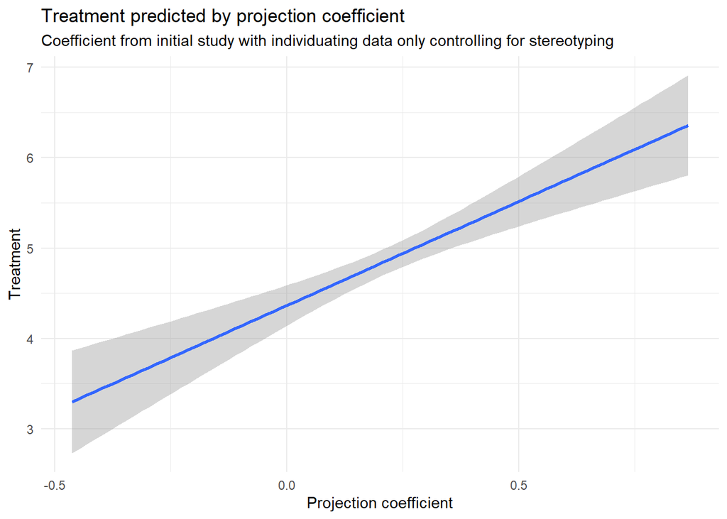

```r
ggplot(downstream_coeffs_indiv,aes(MFQSelf_c, Treatment)) +
  geom_smooth(method = "lm") +
  labs(title = "Treatment predicted by projection coefficient",
       subtitle = "Coefficient from initial study with individuating data only controlling for stereotyping",
       x = "Projection coefficient") +
  theme_minimal()
```

Treatment effects with individuating and binding data look pretty much the same as the overall model.

## Validity predicted by coefficients

```r
valid_coeffs <- lm(Valid ~ MFQSelf_c*`MFQSelf_c:inoutgroup_effects`*`MFQSelf_c:ident_c`*`MFQSelf_c:inoutgroup_effects:ident_c`, data = downstream_coeffs)
summary(valid_coeffs)
```

```
##
## Call:
## lm(formula = Valid ~ MFQSelf_c * `MFQSelf_c:inoutgroup_effects` *
##     `MFQSelf_c:ident_c` * `MFQSelf_c:inoutgroup_effects:ident_c`,
##     data = downstream_coeffs)
##
## Residuals:
##    Min     1Q Median     3Q    Max
## -4.839 -1.548  0.519  1.595  3.420
##
## Coefficients: (14 not defined because of singularities)
##                                                                                                     Estimate
## (Intercept)                                                                                          4.53539
## MFQSelf_c                                                                                            2.14270
## `MFQSelf_c:inoutgroup_effects`                                                                            NA
## `MFQSelf_c:ident_c`                                                                                       NA
## `MFQSelf_c:inoutgroup_effects:ident_c`                                                                    NA
## MFQSelf_c:`MFQSelf_c:inoutgroup_effects`                                                                  NA
## MFQSelf_c:`MFQSelf_c:ident_c`                                                                             NA
## `MFQSelf_c:inoutgroup_effects`:`MFQSelf_c:ident_c`                                                        NA
## MFQSelf_c:`MFQSelf_c:inoutgroup_effects:ident_c`                                                          NA
## `MFQSelf_c:inoutgroup_effects`:`MFQSelf_c:inoutgroup_effects:ident_c`                                     NA
## `MFQSelf_c:ident_c`:`MFQSelf_c:inoutgroup_effects:ident_c`                                                NA
## MFQSelf_c:`MFQSelf_c:inoutgroup_effects`:`MFQSelf_c:ident_c`                                              NA
## MFQSelf_c:`MFQSelf_c:inoutgroup_effects`:`MFQSelf_c:inoutgroup_effects:ident_c`                           NA
## MFQSelf_c:`MFQSelf_c:ident_c`:`MFQSelf_c:inoutgroup_effects:ident_c`                                      NA
## `MFQSelf_c:inoutgroup_effects`:`MFQSelf_c:ident_c`:`MFQSelf_c:inoutgroup_effects:ident_c`                 NA
## MFQSelf_c:`MFQSelf_c:inoutgroup_effects`:`MFQSelf_c:ident_c`:`MFQSelf_c:inoutgroup_effects:ident_c`       NA
##                                                                                                     Std. Error
## (Intercept)                                                                                            0.08455
## MFQSelf_c                                                                                              0.29152
## `MFQSelf_c:inoutgroup_effects`                                                                              NA
## `MFQSelf_c:ident_c`                                                                                         NA
## `MFQSelf_c:inoutgroup_effects:ident_c`                                                                      NA
## MFQSelf_c:`MFQSelf_c:inoutgroup_effects`                                                                    NA
## MFQSelf_c:`MFQSelf_c:ident_c`                                                                               NA
## `MFQSelf_c:inoutgroup_effects`:`MFQSelf_c:ident_c`                                                          NA
## MFQSelf_c:`MFQSelf_c:inoutgroup_effects:ident_c`                                                            NA
## `MFQSelf_c:inoutgroup_effects`:`MFQSelf_c:inoutgroup_effects:ident_c`                                       NA
## `MFQSelf_c:ident_c`:`MFQSelf_c:inoutgroup_effects:ident_c`                                                  NA
```

[output cut: 48 more lines]

```
## MFQSelf_c:`MFQSelf_c:inoutgroup_effects:ident_c`
## `MFQSelf_c:inoutgroup_effects`:`MFQSelf_c:inoutgroup_effects:ident_c`
## `MFQSelf_c:ident_c`:`MFQSelf_c:inoutgroup_effects:ident_c`
## MFQSelf_c:`MFQSelf_c:inoutgroup_effects`:`MFQSelf_c:ident_c`
## MFQSelf_c:`MFQSelf_c:inoutgroup_effects`:`MFQSelf_c:inoutgroup_effects:ident_c`
## MFQSelf_c:`MFQSelf_c:ident_c`:`MFQSelf_c:inoutgroup_effects:ident_c`
## `MFQSelf_c:inoutgroup_effects`:`MFQSelf_c:ident_c`:`MFQSelf_c:inoutgroup_effects:ident_c`
## MFQSelf_c:`MFQSelf_c:inoutgroup_effects`:`MFQSelf_c:ident_c`:`MFQSelf_c:inoutgroup_effects:ident_c`
## ---
## Signif. codes:  0 '***' 0.001 '**' 0.01 '*' 0.05 '.' 0.1 ' ' 1
##
## Residual standard error: 1.903 on 667 degrees of freedom
##   (5 observations deleted due to missingness)
## Multiple R-squared:  0.07493,    Adjusted R-squared:  0.07354
## F-statistic: 54.02 on 1 and 667 DF,  p-value: 0.0000000000005815
```

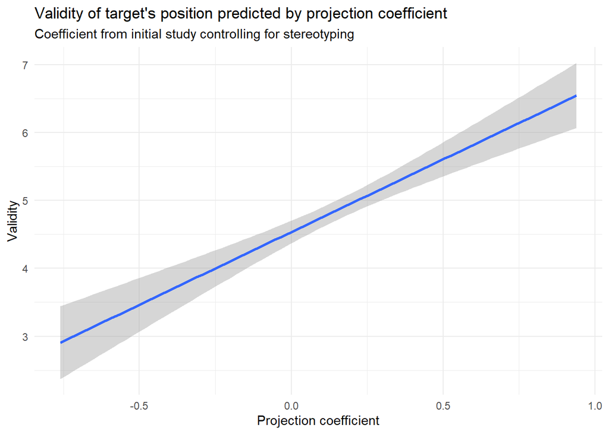

```r
ggplot(downstream_coeffs,aes(MFQSelf_c, Valid)) +
  geom_smooth(method = "lm") +
  labs(title = "Validity of target's position predicted by projection coefficient",
       subtitle = "Coefficient from initial study controlling for stereotyping",
       x = "Projection coefficient",
       y = "Validity") +
  theme_minimal()
```

### Validity with difference scores too

```r
valid_codiff <- lm(Valid ~ MFQSelf_c*proj_diff, coeffs_and_diffs)
summary(valid_codiff)
```

```
##
## Call:
## lm(formula = Valid ~ MFQSelf_c * proj_diff, data = coeffs_and_diffs)
##
## Residuals:
##     Min      1Q  Median      3Q     Max
## -4.9623 -1.3315  0.5359  1.4941  4.0047
##
## Coefficients:
##                     Estimate Std. Error t value             Pr(>|t|)
## (Intercept)           5.0766     0.1377  36.863 < 0.0000000000000002 ***
## MFQSelf_c             1.6560     0.4754   3.484             0.000527 ***
## proj_diff            -0.8204     0.1556  -5.273          0.000000181 ***
## MFQSelf_c:proj_diff   0.1479     0.6065   0.244             0.807380
## ---
## Signif. codes:  0 '***' 0.001 '**' 0.01 '*' 0.05 '.' 0.1 ' ' 1
##
## Residual standard error: 1.861 on 665 degrees of freedom
##   (5 observations deleted due to missingness)
## Multiple R-squared:  0.1179, Adjusted R-squared:  0.1139
## F-statistic: 29.63 on 3 and 665 DF,  p-value: < 0.00000000000000022
```

Both have main effects but the interaction is not significant.

### Validity with binding data

```r
valid_coeff_bind <- lm(Valid ~ MFQSelf_c*`MFQSelf_c:inoutgroup_effects`*`MFQSelf_c:ident_c`*`MFQSelf_c:inoutgroup_effects:ident_c`, data = downstream_coeffs_bind)
summary(valid_coeff_bind)
```

```
##
## Call:
## lm(formula = Valid ~ MFQSelf_c * `MFQSelf_c:inoutgroup_effects` *
##     `MFQSelf_c:ident_c` * `MFQSelf_c:inoutgroup_effects:ident_c`,
##     data = downstream_coeffs_bind)
##
## Residuals:
##     Min      1Q  Median      3Q     Max
## -4.7196 -1.4663  0.4361  1.6767  2.9226
##
## Coefficients: (14 not defined because of singularities)
##                                                                                                     Estimate
## (Intercept)                                                                                          4.54937
## MFQSelf_c                                                                                            2.32294
## `MFQSelf_c:inoutgroup_effects`                                                                            NA
## `MFQSelf_c:ident_c`                                                                                       NA
## `MFQSelf_c:inoutgroup_effects:ident_c`                                                                    NA
## MFQSelf_c:`MFQSelf_c:inoutgroup_effects`                                                                  NA
## MFQSelf_c:`MFQSelf_c:ident_c`                                                                             NA
## `MFQSelf_c:inoutgroup_effects`:`MFQSelf_c:ident_c`                                                        NA
## MFQSelf_c:`MFQSelf_c:inoutgroup_effects:ident_c`                                                          NA
## `MFQSelf_c:inoutgroup_effects`:`MFQSelf_c:inoutgroup_effects:ident_c`                                     NA
## `MFQSelf_c:ident_c`:`MFQSelf_c:inoutgroup_effects:ident_c`                                                NA
## MFQSelf_c:`MFQSelf_c:inoutgroup_effects`:`MFQSelf_c:ident_c`                                              NA
## MFQSelf_c:`MFQSelf_c:inoutgroup_effects`:`MFQSelf_c:inoutgroup_effects:ident_c`                           NA
## MFQSelf_c:`MFQSelf_c:ident_c`:`MFQSelf_c:inoutgroup_effects:ident_c`                                      NA
## `MFQSelf_c:inoutgroup_effects`:`MFQSelf_c:ident_c`:`MFQSelf_c:inoutgroup_effects:ident_c`                 NA
## MFQSelf_c:`MFQSelf_c:inoutgroup_effects`:`MFQSelf_c:ident_c`:`MFQSelf_c:inoutgroup_effects:ident_c`       NA
##                                                                                                     Std. Error
## (Intercept)                                                                                            0.09725
## MFQSelf_c                                                                                              0.48986
## `MFQSelf_c:inoutgroup_effects`                                                                              NA
## `MFQSelf_c:ident_c`                                                                                         NA
## `MFQSelf_c:inoutgroup_effects:ident_c`                                                                      NA
## MFQSelf_c:`MFQSelf_c:inoutgroup_effects`                                                                    NA
## MFQSelf_c:`MFQSelf_c:ident_c`                                                                               NA
## `MFQSelf_c:inoutgroup_effects`:`MFQSelf_c:ident_c`                                                          NA
## MFQSelf_c:`MFQSelf_c:inoutgroup_effects:ident_c`                                                            NA
## `MFQSelf_c:inoutgroup_effects`:`MFQSelf_c:inoutgroup_effects:ident_c`                                       NA
## `MFQSelf_c:ident_c`:`MFQSelf_c:inoutgroup_effects:ident_c`                                                  NA
```

[output cut: 47 more lines]

```
## `MFQSelf_c:inoutgroup_effects`:`MFQSelf_c:ident_c`
## MFQSelf_c:`MFQSelf_c:inoutgroup_effects:ident_c`
## `MFQSelf_c:inoutgroup_effects`:`MFQSelf_c:inoutgroup_effects:ident_c`
## `MFQSelf_c:ident_c`:`MFQSelf_c:inoutgroup_effects:ident_c`
## MFQSelf_c:`MFQSelf_c:inoutgroup_effects`:`MFQSelf_c:ident_c`
## MFQSelf_c:`MFQSelf_c:inoutgroup_effects`:`MFQSelf_c:inoutgroup_effects:ident_c`
## MFQSelf_c:`MFQSelf_c:ident_c`:`MFQSelf_c:inoutgroup_effects:ident_c`
## `MFQSelf_c:inoutgroup_effects`:`MFQSelf_c:ident_c`:`MFQSelf_c:inoutgroup_effects:ident_c`
## MFQSelf_c:`MFQSelf_c:inoutgroup_effects`:`MFQSelf_c:ident_c`:`MFQSelf_c:inoutgroup_effects:ident_c`
## ---
## Signif. codes:  0 '***' 0.001 '**' 0.01 '*' 0.05 '.' 0.1 ' ' 1
##
## Residual standard error: 1.946 on 667 degrees of freedom
## Multiple R-squared:  0.03261,    Adjusted R-squared:  0.03116
## F-statistic: 22.49 on 1 and 667 DF,  p-value: 0.000002589
```

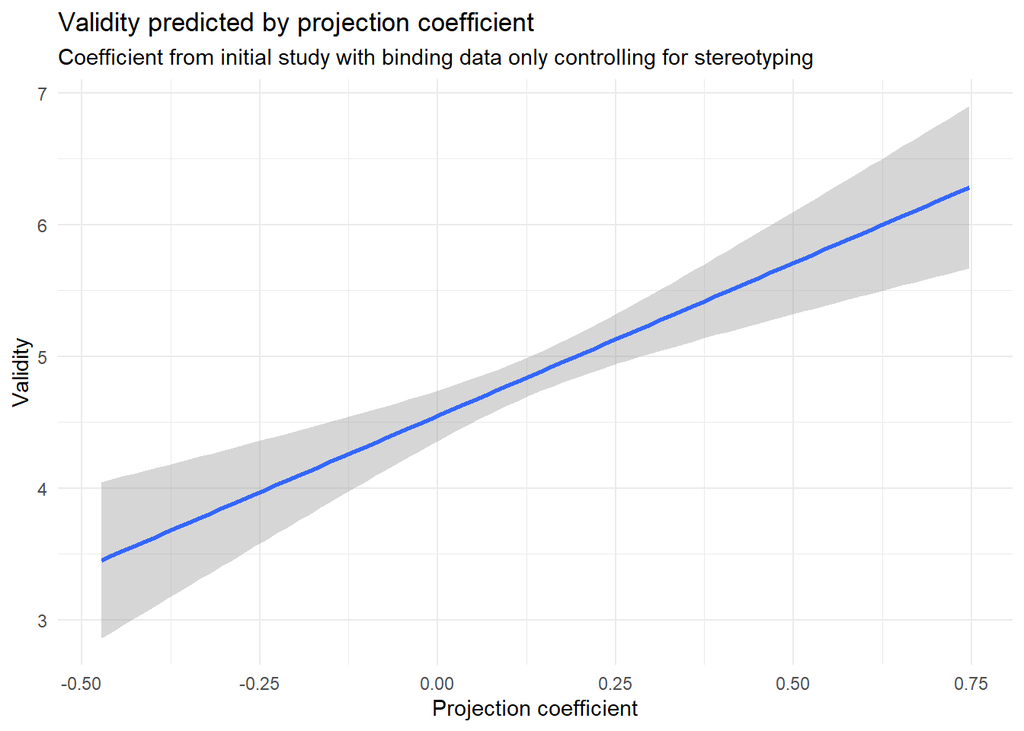

```r
ggplot(downstream_coeffs_bind,aes(MFQSelf_c, Valid)) +
  geom_smooth(method = "lm") +
  labs(title = "Validity predicted by projection coefficient",
       subtitle = "Coefficient from initial study with binding data only controlling for stereotyping",
       x = "Projection coefficient",
       y = "Validity") +
  theme_minimal()
```

### Validity with individuating data

```r
valid_coeff_indiv <- lm(Valid ~ MFQSelf_c*`MFQSelf_c:inoutgroup_effects`*`MFQSelf_c:ident_c`*`MFQSelf_c:inoutgroup_effects:ident_c`, data = downstream_coeffs_indiv)
summary(valid_coeff_indiv)
```

```
##
## Call:
## lm(formula = Valid ~ MFQSelf_c * `MFQSelf_c:inoutgroup_effects` *
##     `MFQSelf_c:ident_c` * `MFQSelf_c:inoutgroup_effects:ident_c`,
##     data = downstream_coeffs_indiv)
##
## Residuals:
##    Min     1Q Median     3Q    Max
## -4.622 -1.452  0.492  1.731  3.061
##
## Coefficients: (14 not defined because of singularities)
##                                                                                                     Estimate
## (Intercept)                                                                                           4.4421
## MFQSelf_c                                                                                             1.8915
## `MFQSelf_c:inoutgroup_effects`                                                                            NA
## `MFQSelf_c:ident_c`                                                                                       NA
## `MFQSelf_c:inoutgroup_effects:ident_c`                                                                    NA
## MFQSelf_c:`MFQSelf_c:inoutgroup_effects`                                                                  NA
## MFQSelf_c:`MFQSelf_c:ident_c`                                                                             NA
## `MFQSelf_c:inoutgroup_effects`:`MFQSelf_c:ident_c`                                                        NA
## MFQSelf_c:`MFQSelf_c:inoutgroup_effects:ident_c`                                                          NA
## `MFQSelf_c:inoutgroup_effects`:`MFQSelf_c:inoutgroup_effects:ident_c`                                     NA
## `MFQSelf_c:ident_c`:`MFQSelf_c:inoutgroup_effects:ident_c`                                                NA
## MFQSelf_c:`MFQSelf_c:inoutgroup_effects`:`MFQSelf_c:ident_c`                                              NA
## MFQSelf_c:`MFQSelf_c:inoutgroup_effects`:`MFQSelf_c:inoutgroup_effects:ident_c`                           NA
## MFQSelf_c:`MFQSelf_c:ident_c`:`MFQSelf_c:inoutgroup_effects:ident_c`                                      NA
## `MFQSelf_c:inoutgroup_effects`:`MFQSelf_c:ident_c`:`MFQSelf_c:inoutgroup_effects:ident_c`                 NA
## MFQSelf_c:`MFQSelf_c:inoutgroup_effects`:`MFQSelf_c:ident_c`:`MFQSelf_c:inoutgroup_effects:ident_c`       NA
##                                                                                                     Std. Error
## (Intercept)                                                                                             0.1182
## MFQSelf_c                                                                                               0.4310
## `MFQSelf_c:inoutgroup_effects`                                                                              NA
## `MFQSelf_c:ident_c`                                                                                         NA
## `MFQSelf_c:inoutgroup_effects:ident_c`                                                                      NA
## MFQSelf_c:`MFQSelf_c:inoutgroup_effects`                                                                    NA
## MFQSelf_c:`MFQSelf_c:ident_c`                                                                               NA
## `MFQSelf_c:inoutgroup_effects`:`MFQSelf_c:ident_c`                                                          NA
## MFQSelf_c:`MFQSelf_c:inoutgroup_effects:ident_c`                                                            NA
## `MFQSelf_c:inoutgroup_effects`:`MFQSelf_c:inoutgroup_effects:ident_c`                                       NA
## `MFQSelf_c:ident_c`:`MFQSelf_c:inoutgroup_effects:ident_c`                                                  NA
```

[output cut: 47 more lines]

```
## `MFQSelf_c:inoutgroup_effects`:`MFQSelf_c:ident_c`
## MFQSelf_c:`MFQSelf_c:inoutgroup_effects:ident_c`
## `MFQSelf_c:inoutgroup_effects`:`MFQSelf_c:inoutgroup_effects:ident_c`
## `MFQSelf_c:ident_c`:`MFQSelf_c:inoutgroup_effects:ident_c`
## MFQSelf_c:`MFQSelf_c:inoutgroup_effects`:`MFQSelf_c:ident_c`
## MFQSelf_c:`MFQSelf_c:inoutgroup_effects`:`MFQSelf_c:inoutgroup_effects:ident_c`
## MFQSelf_c:`MFQSelf_c:ident_c`:`MFQSelf_c:inoutgroup_effects:ident_c`
## `MFQSelf_c:inoutgroup_effects`:`MFQSelf_c:ident_c`:`MFQSelf_c:inoutgroup_effects:ident_c`
## MFQSelf_c:`MFQSelf_c:inoutgroup_effects`:`MFQSelf_c:ident_c`:`MFQSelf_c:inoutgroup_effects:ident_c`
## ---
## Signif. codes:  0 '***' 0.001 '**' 0.01 '*' 0.05 '.' 0.1 ' ' 1
##
## Residual standard error: 1.951 on 667 degrees of freedom
## Multiple R-squared:  0.02807,    Adjusted R-squared:  0.02661
## F-statistic: 19.26 on 1 and 667 DF,  p-value: 0.00001326
```

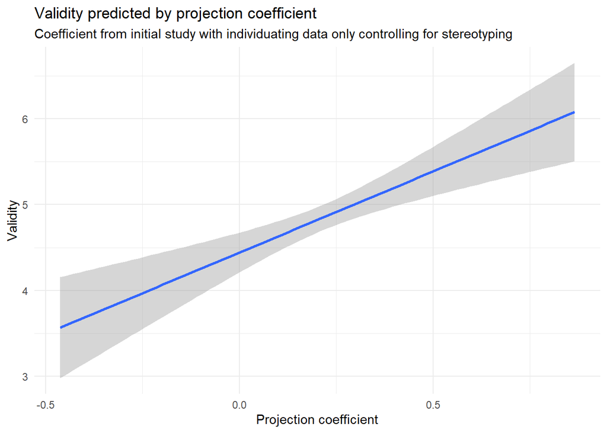

```r
ggplot(downstream_coeffs_indiv,aes(MFQSelf_c, Valid)) +
  geom_smooth(method = "lm") +
  labs(title = "Validity predicted by projection coefficient",
       subtitle = "Coefficient from initial study with individuating data only controlling for stereotyping",
       x = "Projection coefficient",
       y = "Validity") +
  theme_minimal()
```

Models using the individuating and binding data look the same as the overall model.